# Evidencia 2 | Proyecto Integrador

Karina Ruiz Tron A01656073

2022-05-04

## Segunda Entrega

### Parte 1

- Investigación **1. ¿Cuáles son los virus “similares” a SARS-CoV-2 en el mundo?** Los virus Epstein-Barr virus (EBV), cytomegalovirus (CMV) y human immunodeficiency virus (HIV) tienen similitudes con el SARS-CoV-2 en sus manifestaciones, es decir, estos virus comparten la capacidad de crear habilidades autoinmunes.

**2. ¿Cuáles son los coronavirus reportados en otras especies que pueden ser cercanos al genoma de SARS-CoV-2?** Existen coronavirus que también son capaces de afectar a los animales, dos ejemplos de estos, según un artículo publicado por Christine Haake, Sarah Cook, Nicola Pusterla y Brian Murphy, son: el coronavirus felino (FECV, por sus siglas en inglés) el cual, como menciona su nombre, afecta a los gatos y el coronavirus equino, que afecta a los caballos.

**3. En relación con la situación actual reflexiona, ¿qué propondrías que se deba hacer durante la contingencia del SARS-CoV-2 en comunidades de bajos recursos? Si tu vivieras en una situación de escasos recursos, ¿qué harías?** Primero me encargaría de conocer las necesidades que tengan las personas de la comunidad referente al tema de la salud, apartir de eso crearía un plan de acción adecuado a esas necesidades. Aunque, sí he de escoger algo en lo que me concentraría primero, sería en crear campañas de vacunación y contactar con enfermeras voluntarias que pudieran trasladarse hasta esas comunidades. En el caso de yo vivir en una situación de escasos recursos, me encargaría de hacer campañas con mi comunidad. Primero buscaría información en bibliotecas o con recursos que pueda conseguir, para posteriormente, compartir esa información con mi comunidad y así poder mencionar los cuidados que deberíamos de tener, por ejemplo, el uso del cubrebocas o lavarse las manos con frecuencia.

**Link del video:** https://youtu.be/pK3SErhOecw

### Parte 2

**1. Opción que elegí** Trabajar con las secuencias de los coronavirus de otras especies que son similares a SARS-CoV-2, para tratar de explicar el fenómeno de zoonosis del virus. * Las secuencias de coronavirus con las que estaré trabajando son las siguientes: + Coronavirus de pato (KM454473) (CP) + Coronavirus de murciélago (EF065511) (CM) + Coronavirus de erizo común (MK907287) (CEC) + Coronavirus de paguma larvata (AY515512) (CPL) + Coronavirus de conejo (JN874560) (CC) + Coronavirus de faisán (MK423876) (CF) + Virus de bronquitis infecciosa aviar (KX185057) (VBIA) + Coronavirus de civeta común de las palmeras (AY613948) (CCCP) + Coronavirus de Yak (MH810163) (CY) + Coronavirus respiratorio canino (KX432213) (CRC) + Coronavirus porcino (KY994645) (CVP) + Coronavirus de rata gris (KM349742) (CRG) + Pipisbtrellus abramus bat coronavirus (MN611520) (PABC) + Tylonycteris pachypus bat coronavirus (KJ473822) (TPBC) + Vespertilio sinensis bat coronavirus (KJ473821) (VSBC) + Hypsugo bat coronavirus (KX442564) (HBC) + Rhinolophus sinicus bat coronavirus (KY417150) (RSBC) + Aselliscus stoliczkanus bat coronavirus (KY417142) (ASBC) + Myotis daubentonii bat coronavirus (KU182965) (MSBC) + Rousettus bat coronavirus (NC_030886) (RBC)

**2. Longitud de las secuencias**

```r
#install.packages("seqinr")
library("seqinr")

#secuencia 1
CP <- read.fasta("/Users/karinaruiztron/Downloads/Programas de programacion/R/Evidencia2_bio/CP.fasta")
class(CP)
```

```
## [1] "list"
```

```r
str(CP)
```

```
## List of 1
##  $ KM454473.1: 'SeqFastadna' chr [1:27754] "t" "g" "c" "t" ...
##   ..- attr(*, "name")= chr "KM454473.1"
##   ..- attr(*, "Annot")= chr ">KM454473.1 Duck coronavirus isolate DK/GD/27/2014, complete genome"
```

```r
length(CP[[1]])
```

```
## [1] 27754
```

```r
#secuencia 2
CM <- read.fasta("/Users/karinaruiztron/Downloads/Programas de programacion/R/Evidencia2_bio/CM.fasta")
class(CM)
```

```
## [1] "list"
```

```r
str(CM)
```

```
## List of 1
##  $ EF065511.1: 'SeqFastadna' chr [1:30488] "g" "a" "t" "t" ...
##   ..- attr(*, "name")= chr "EF065511.1"
##   ..- attr(*, "Annot")= chr ">EF065511.1 Bat coronavirus HKU5-3, complete genome"
```

```r
length(CM[[1]])
```

```
## [1] 30488
```

```r
#secuencia 3
CEC <- read.fasta("/Users/karinaruiztron/Downloads/Programas de programacion/R/Evidencia2_bio/CEC.fasta")
class(CEC)
```

```
## [1] "list"
```

```r
str(CEC)
```

```
## List of 1
##  $ MK907287.1: 'SeqFastadna' chr [1:29951] "g" "a" "t" "t" ...
##   ..- attr(*, "name")= chr "MK907287.1"
##   ..- attr(*, "Annot")= chr ">MK907287.1 Erinaceus hedgehog coronavirus HKU31 strain Rs13, complete genome"
```

```r
length(CEC[[1]])
```

```
## [1] 29951
```

```r
#secuencia 4
CPL <- read.fasta("/Users/karinaruiztron/Downloads/Programas de programacion/R/Evidencia2_bio/CPL.fasta")
class(CPL)
```

```
## [1] "list"
```

```r
str(CPL)
```

```
## List of 1
##  $ AY515512.1: 'SeqFastadna' chr [1:29731] "g" "a" "a" "a" ...
##   ..- attr(*, "name")= chr "AY515512.1"
##   ..- attr(*, "Annot")= chr ">AY515512.1 SARS coronavirus HC/SZ/61/03, complete genome"
```

```r
length(CPL[[1]])
```

```
## [1] 29731
```

```r
#secuencia 5
CC <- read.fasta("/Users/karinaruiztron/Downloads/Programas de programacion/R/Evidencia2_bio/CC.fasta")
class(CC)
```

```
## [1] "list"
```

```r
str(CC)
```

```
## List of 1
##  $ JN874560.1: 'SeqFastadna' chr [1:31116] "g" "a" "t" "t" ...
##   ..- attr(*, "name")= chr "JN874560.1"
##   ..- attr(*, "Annot")= chr ">JN874560.1 Rabbit coronavirus HKU14 strain HKU14-3, complete genome"
```

```r
length(CC[[1]])
```

```
## [1] 31116
```

```r
#secuencia 6
CF <- read.fasta("/Users/karinaruiztron/Downloads/Programas de programacion/R/Evidencia2_bio/CF.fasta")
class(CF)
```

```
## [1] "list"
```

```r
str(CF)
```

```
## List of 1
##  $ MK423876.1: 'SeqFastadna' chr [1:27655] "a" "c" "t" "a" ...
##   ..- attr(*, "name")= chr "MK423876.1"
##   ..- attr(*, "Annot")= chr ">MK423876.1 Pheasant coronavirus strain gammaCoV/ph/China/I0710/17, complete genome"
```

```r
length(CF[[1]])
```

```
## [1] 27655
```

```r
#secuencia 7
VBIA <- read.fasta("/Users/karinaruiztron/Downloads/Programas de programacion/R/Evidencia2_bio/VBIA.fasta")
class(VBIA)
```

```
## [1] "list"
```

```r
str(VBIA)
```

```
## List of 1
##  $ KX185057.1: 'SeqFastadna' chr [1:27802] "a" "c" "t" "g" ...
##   ..- attr(*, "name")= chr "KX185057.1"
##   ..- attr(*, "Annot")= chr ">KX185057.1 Infectious bronchitis virus strain ck/CH/LHLJ/95I, complete genome"
```

```r
length(VBIA[[1]])
```

```
## [1] 27802
```

```r
#secuencia 8
CCCP <- read.fasta("/Users/karinaruiztron/Downloads/Programas de programacion/R/Evidencia2_bio/CCCP.fasta")
class(CCCP)
```

```
## [1] "list"
```

```r
str(CCCP)
```

```
## List of 1
##  $ AY613948.1: 'SeqFastadna' chr [1:29730] "t" "a" "g" "a" ...
##   ..- attr(*, "name")= chr "AY613948.1"
##   ..- attr(*, "Annot")= chr ">AY613948.1 SARS coronavirus PC4-13, complete genome"
```

```r
length(CCCP[[1]])
```

```
## [1] 29730
```

```r
#secuencia 9
CY <- read.fasta("/Users/karinaruiztron/Downloads/Programas de programacion/R/Evidencia2_bio/CY.fasta")
class(CY)
```

```
## [1] "list"
```

```r
str(CY)
```

```
## List of 1
##  $ MH810163.1: 'SeqFastadna' chr [1:31032] "g" "a" "t" "t" ...
##   ..- attr(*, "name")= chr "MH810163.1"
##   ..- attr(*, "Annot")= chr ">MH810163.1 Yak coronavirus strain YAK/HY24/CH/2017, complete genome"
```

```r
length(CY[[1]])
```

```
## [1] 31032
```

```r
#secuencia 10
CRC <- read.fasta("/Users/karinaruiztron/Downloads/Programas de programacion/R/Evidencia2_bio/CRC.fasta")
class(CRC)
```

```
## [1] "list"
```

```r
str(CRC)
```

```
## List of 1
##  $ KX432213.1: 'SeqFastadna' chr [1:30868] "a" "a" "c" "t" ...
##   ..- attr(*, "name")= chr "KX432213.1"
##   ..- attr(*, "Annot")= chr ">KX432213.1 Canine respiratory coronavirus strain BJ232, complete genome"
```

```r
length(CRC[[1]])
```

```
## [1] 30868
```

```r
#Grupo 1
grupof1 <- c(CP,CM,CEC,CPL,CC,CF,VBIA,CCCP,CY,CRC)
grupo1 <- c("CP","CM","CEC","CPL","CC","CF","VBIA","CCCP","CY","CRC")

#secuencia 11
CVP <- read.fasta("/Users/karinaruiztron/Downloads/Programas de programacion/R/Evidencia2_bio/CVP.fasta")
class(CVP)
```

```
## [1] "list"
```

```r
str(CVP)
```

```
## List of 1
##  $ KY994645.1: 'SeqFastadna' chr [1:30684] "g" "a" "t" "t" ...
##   ..- attr(*, "name")= chr "KY994645.1"
##   ..- attr(*, "Annot")= chr ">KY994645.1 Porcine hemagglutinating encephalomyelitis virus strain JL/2008, complete genome"
```

```r
length(CVP[[1]])
```

```
## [1] 30684
```

```r
#secuencia 12
CRG <- read.fasta("/Users/karinaruiztron/Downloads/Programas de programacion/R/Evidencia2_bio/CRG.fasta")
class(CRG)
```

```
## [1] "list"
```

```r
str(CRG)
```

```
## List of 1
##  $ KM349742.1: 'SeqFastadna' chr [1:31249] "g" "a" "t" "a" ...
##   ..- attr(*, "name")= chr "KM349742.1"
##   ..- attr(*, "Annot")= chr ">KM349742.1 Betacoronavirus HKU24 strain HKU24-R05005I, complete genome"
```

```r
length(CRG[[1]])
```

```
## [1] 31249
```

```r
#secuencia 13
PABC <- read.fasta("/Users/karinaruiztron/Downloads/Programas de programacion/R/Evidencia2_bio/PABC.fasta")
class(PABC)
```

```
## [1] "list"
```

```r
str(PABC)
```

```
## List of 1
##  $ MN611520.1: 'SeqFastadna' chr [1:30511] "c" "t" "a" "g" ...
##   ..- attr(*, "name")= chr "MN611520.1"
##   ..- attr(*, "Annot")= chr ">MN611520.1 Pipistrellus abramus bat coronavirus HKU5-related isolate BY140568, complete genome"
```

```r
length(PABC[[1]])
```

```
## [1] 30511
```

```r
#secuencia 14
TPBC <- read.fasta("/Users/karinaruiztron/Downloads/Programas de programacion/R/Evidencia2_bio/TPBC.fasta")
class(TPBC)
```

```
## [1] "list"
```

```r
str(TPBC)
```

```
## List of 1
##  $ KJ473822.1: 'SeqFastadna' chr [1:30247] "t" "t" "t" "t" ...
##   ..- attr(*, "name")= chr "KJ473822.1"
##   ..- attr(*, "Annot")= chr ">KJ473822.1 BtTp-BetaCoV/GX2012, complete genome"
```

```r
length(TPBC[[1]])
```

```
## [1] 30247
```

```r
#secuencia 15
VSBC <- read.fasta("/Users/karinaruiztron/Downloads/Programas de programacion/R/Evidencia2_bio/VSBC.fasta")
class(VSBC)
```

```
## [1] "list"
```

```r
str(VSBC)
```

```
## List of 1
##  $ KJ473821.1: 'SeqFastadna' chr [1:30423] "g" "a" "t" "t" ...
##   ..- attr(*, "name")= chr "KJ473821.1"
##   ..- attr(*, "Annot")= chr ">KJ473821.1 BtVs-BetaCoV/SC2013, complete genome"
```

```r
length(VSBC[[1]])
```

```
## [1] 30423
```

```r
#secuencia 16
HBC <- read.fasta("/Users/karinaruiztron/Downloads/Programas de programacion/R/Evidencia2_bio/HBC.fasta")
class(HBC)
```

```
## [1] "list"
```

```r
str(HBC)
```

```
## List of 1
##  $ KX442564.1: 'SeqFastadna' chr [1:30498] "g" "a" "t" "t" ...
##   ..- attr(*, "name")= chr "KX442564.1"
##   ..- attr(*, "Annot")= chr ">KX442564.1 Hypsugo bat coronavirus HKU25 isolate YD131305, complete genome"
```

```r
length(HBC[[1]])
```

```
## [1] 30498
```

```r
#secuencia 17
RSBC <- read.fasta("/Users/karinaruiztron/Downloads/Programas de programacion/R/Evidencia2_bio/RSBC.fasta")
class(RSBC)
```

```
## [1] "list"
```

```r
str(RSBC)
```

```
## List of 1
##  $ KY417150.1: 'SeqFastadna' chr [1:30311] "a" "t" "a" "t" ...
##   ..- attr(*, "name")= chr "KY417150.1"
##   ..- attr(*, "Annot")= chr ">KY417150.1 Bat SARS-like coronavirus isolate Rs4874, complete genome"
```

```r
length(RSBC[[1]])
```

```
## [1] 30311
```

```r
#secuencia 18
ASBC <- read.fasta("/Users/karinaruiztron/Downloads/Programas de programacion/R/Evidencia2_bio/ASBC.fasta")
class(ASBC)
```

```
## [1] "list"
```

```r
str(ASBC)
```

```
## List of 1
##  $ KY417142.1: 'SeqFastadna' chr [1:29725] "a" "t" "a" "t" ...
##   ..- attr(*, "name")= chr "KY417142.1"
##   ..- attr(*, "Annot")= chr ">KY417142.1 Bat SARS-like coronavirus isolate As6526, complete genome"
```

```r
length(ASBC[[1]])
```

```
## [1] 29725
```

```r
#secuencia 19
MSBC <- read.fasta("/Users/karinaruiztron/Downloads/Programas de programacion/R/Evidencia2_bio/MSBC.fasta")
class(MSBC)
```

```
## [1] "list"
```

```r
str(MSBC)
```

```
## List of 1
##  $ KU182965.1: 'SeqFastadna' chr [1:30321] "a" "a" "t" "t" ...
##   ..- attr(*, "name")= chr "KU182965.1"
##   ..- attr(*, "Annot")= chr ">KU182965.1 Bat coronavirus isolate JPDB144, complete genome"
```

```r
length(MSBC[[1]])
```

```
## [1] 30321
```

```r
#secuencia 20
RBC <- read.fasta("/Users/karinaruiztron/Downloads/Programas de programacion/R/Evidencia2_bio/RBC.fasta")
class(RBC)
```

```
## [1] "list"
```

```r
str(RBC)
```

```
## List of 1
##  $ NC_030886.1: 'SeqFastadna' chr [1:30161] "g" "a" "a" "a" ...
##   ..- attr(*, "name")= chr "NC_030886.1"
##   ..- attr(*, "Annot")= chr ">NC_030886.1 Rousettus bat coronavirus isolate GCCDC1 356, complete genome"
```

```r
length(RBC[[1]])
```

```
## [1] 30161
```

```r
#Grupo 2
grupof2 <- c(CVP,CRG,PABC,TPBC,VSBC,HBC,RSBC,ASBC,MSBC,RBC)
grupo2 <- c("CVP","CRG","PABC","TPBC","VSBC","HBC","RSBC","ASBC","MSBC","RBC")
```

**3. Gráfica comparativa del número de bases de las variantes del virus**

[figure not shown]

```r
comparacion <- function(seq){
  CA <-0
  CT <-0
  CC <-0
  CG <-0

  l <- length(seq)

  for(i in seq){

    if(i=="A" || i=="a"){
      CA = CA + 1
    }
    else if(i=="T" || i=="t") {
      CT = CT + 1
    }
    else if(i=="C" || i=="c") {
      CC = CC + 1
    }
    else if(i=="G" || i=="g") {
      CG = CG + 1
    }
  }

  vec<- c(CA,CT,CC, CG)
  return(vec)
}

CP1<- c('#B368ED', '#956DF7', '#706EE0', '#6D8FF7', '#68ACED',  '#79F7B3','#6BDA76', '#B6D654', '#F9F393', '#A4F081', '#FF946B', '#E65D43', '#E32B54', '#FC5E56', '#FF5CC1', '#FF7770', '#E8486C', '#E430E6', '#DC61FF', '#FF5CC0')
CP2<- c('#B368ED', '#956DF7', '#706EE0', '#6D8FF7', '#68ACED',  '#79F7B3','#6BDA76', '#B6D654', '#F9F393', '#A4F081')
CP3<- c('#FF946B', '#E65D43', '#E32B54', '#FC5E56', '#FF5CC1', '#FF7770', '#E8486C', '#E430E6', '#DC61FF', '#FF5CC0')


grupo1 <- c("CP","CM","CEC","CPL","CC","CF","VBIA","CCCP","CY","CRC")
grupo2 <- c("CVP","CRG","PABC","TPBC","VSBC","HBC","RSBC","ASBC","MSBC","RBC")

  funG<- c(f1<-sapply(CP, comparacion),f2<-sapply(CM, comparacion),f3<-sapply(CEC, comparacion),f4<-sapply(CPL, comparacion),f5<-sapply(CC, comparacion),f6<-sapply(CF, comparacion),f7<-sapply(VBIA, comparacion),f8<-sapply(CCCP, comparacion),f9<-sapply(CY, comparacion),f10<-sapply(CRC, comparacion),f11<-sapply(CVP, comparacion),f12<-sapply(CRG, comparacion),f13<-sapply(PABC, comparacion),f14<-sapply(TPBC, comparacion),f15<-sapply(VSBC, comparacion),f16<-sapply(HBC, comparacion),f17<-sapply(RSBC, comparacion),f18<-sapply(ASBC, comparacion),f19<-sapply(MSBC, comparacion),f20<-sapply(RBC, comparacion))

par(mar=c(4,3,0,1))
virus<-barplot(matrix(c(funG), nrow=20, byrow=T), beside=T,  col = CP1, names.arg= c("A","T","G", "C"))
legend("topright", legend = grupo1 ,
     col = CP2 ,bty = "n", pch=18 , pt.cex = 1, cex = 0.6, horiz = FALSE, inset = c(0.3, 0.001))
legend("topright", legend = grupo2 ,
     col = CP3 ,bty = "n", pch=18 , pt.cex = 1, cex = 0.6, horiz = FALSE, inset = c(0.05, 0.001))
```

**4. Análisis jerárquico global**

```r
V <- c("KM454473", "EF065511", "MK907287", "AY515512", "JN874560", "MK423876", "KX185057", "AY613948", "MH810163", "KX432213", "KY994645", "KM349742", "MN611520", "KJ473822", "KJ473821", "KX442564", "KY417150", "KY417142", "KU182965", "NC_030886")

library(Biostrings)
library(seqinr)
library(adegenet)
library(ape)
library(ggtree)
library(DECIPHER)
library(viridis)
```

```r
library(ggplot2)

virus_sequences <- read.GenBank(V)

str(virus_sequences)
```

```
## List of 20
##  $ KM454473 : raw [1:27754] 18 48 28 18 ...
##  $ EF065511 : raw [1:30488] 48 88 18 18 ...
##  $ MK907287 : raw [1:29951] 48 88 18 18 ...
##  $ AY515512 : raw [1:29731] 48 88 88 88 ...
##  $ JN874560 : raw [1:31116] 48 88 18 18 ...
##  $ MK423876 : raw [1:27655] 88 28 18 88 ...
##  $ KX185057 : raw [1:27802] 88 28 18 48 ...
##  $ AY613948 : raw [1:29730] 18 88 48 88 ...
##  $ MH810163 : raw [1:31032] 48 88 18 18 ...
##  $ KX432213 : raw [1:30868] 88 88 28 18 ...
##  $ KY994645 : raw [1:30684] 48 88 18 18 ...
##  $ KM349742 : raw [1:31249] 48 88 18 88 ...
##  $ MN611520 : raw [1:30511] 28 18 88 48 ...
##  $ KJ473822 : raw [1:30247] 18 18 18 18 ...
##  $ KJ473821 : raw [1:30423] 48 88 18 18 ...
##  $ KX442564 : raw [1:30498] 48 88 18 18 ...
##  $ KY417150 : raw [1:30311] 88 18 88 18 ...
##  $ KY417142 : raw [1:29725] 88 18 88 18 ...
##  $ KU182965 : raw [1:30321] 88 88 18 18 ...
##  $ NC_030886: raw [1:30161] 48 88 88 88 ...
##  - attr(*, "class")= chr "DNAbin"
##  - attr(*, "description")= chr [1:20] "KM454473.1 Duck coronavirus isolate DK/GD/27/2014, complete genome" "EF065511.1 Bat coronavirus HKU5-3, complete genome" "MK907287.1 Erinaceus hedgehog coronavirus HKU31 strain Rs13, complete genome" "AY515512.1 SARS coronavirus HC/SZ/61/03, complete genome"…
##  - attr(*, "species")= chr [1:20] "Duck_coronavirus" "Bat_coronavirus_HKU5-3" "Erinaceus_hedgehog_coronavirus_HKU31" "SARS_coronavirus_HC/SZ/61/03" ...
```

```r
attributes(virus_sequences)
```

```
## $names
##  [1] "KM454473"  "EF065511"  "MK907287"  "AY515512"  "JN874560"  "MK423876"
##  [7] "KX185057"  "AY613948"  "MH810163"  "KX432213"  "KY994645"  "KM349742"
## [13] "MN611520"  "KJ473822"  "KJ473821"  "KX442564"  "KY417150"  "KY417142"
## [19] "KU182965"  "NC_030886"
##
## $class
## [1] "DNAbin"
##
## $description
##  [1] "KM454473.1 Duck coronavirus isolate DK/GD/27/2014, complete genome"
##  [2] "EF065511.1 Bat coronavirus HKU5-3, complete genome"
##  [3] "MK907287.1 Erinaceus hedgehog coronavirus HKU31 strain Rs13, complete genome"
##  [4] "AY515512.1 SARS coronavirus HC/SZ/61/03, complete genome"
##  [5] "JN874560.1 Rabbit coronavirus HKU14 strain HKU14-3, complete genome"
```

[output cut: 37 more lines]

```r
names(virus_sequences)
```

```
##  [1] "KM454473"  "EF065511"  "MK907287"  "AY515512"  "JN874560"  "MK423876"
##  [7] "KX185057"  "AY613948"  "MH810163"  "KX432213"  "KY994645"  "KM349742"
## [13] "MN611520"  "KJ473822"  "KJ473821"  "KX442564"  "KY417150"  "KY417142"
## [19] "KU182965"  "NC_030886"
```

```r
attr(virus_sequences, "species")
```

```
##  [1] "Duck_coronavirus"
##  [2] "Bat_coronavirus_HKU5-3"
##  [3] "Erinaceus_hedgehog_coronavirus_HKU31"
##  [4] "SARS_coronavirus_HC/SZ/61/03"
##  [5] "Rabbit_coronavirus_HKU14"
##  [6] "Pheasant_coronavirus"
##  [7] "Infectious_bronchitis_virus"
##  [8] "SARS_coronavirus_PC4-13"
##  [9] "Yak_coronavirus"
## [10] "Canine_respiratory_coronavirus"
## [11] "Porcine_hemagglutinating_encephalomyelitis_virus"
## [12] "Betacoronavirus_HKU24"
## [13] "Pipistrellus_abramus_bat_coronavirus_HKU5-related"
## [14] "BtTp-BetaCoV/GX2012"
## [15] "BtVs-BetaCoV/SC2013"
## [16] "Hypsugo_bat_coronavirus_HKU25"
## [17] "Bat_SARS-like_coronavirus"
## [18] "Bat_SARS-like_coronavirus"
## [19] "Bat_coronavirus"
## [20] "Rousettus_bat_coronavirus"
```

```r
write.dna(virus_sequences,
          file ="virus_seqs.fasta",
          format = "fasta",
          append = FALSE,
          nbcol = 6,
          colsep = " ",
          colw = 10)

virus_seq_not_align <- readDNAStringSet("virus_seqs.fasta", format = "fasta")
virus_seq_not_align
```

```
## DNAStringSet object of length 20:
##      width seq                                              names
##  [1] 27754 TGCTGGTATCACTGCTTGTTAGG...AAAAAAAAAAAAAAAAAAAAAA KM454473
##  [2] 30488 GATTTAAGAGAATAGCCTAGCTA...ATTTGCAAAAAAAAAAAAAAAA EF065511
##  [3] 29951 GATTAAAGAGAATAGCATAGCTA...GGTGATTTGCAAAAAAAAAAAA MK907287
##  [4] 29731 GAAAAGCCAACCAACCTCGATCT...TTAATAGCTTCTTAGGAGAATC AY515512
##  [5] 31116 GATTCTGAGCGATTTGCGTGCGT...AATCACAAAAAAAAAAAAAAAA JN874560
##  ...   ... ...
## [16] 30498 GATTTAAGTGAATAGCCTAGCTA...ATTAACAAAAAAAAAAAAAAAA KX442564
## [17] 30311 ATATTAGGTTTTTACCTACCCAG...AAAAAAAAAAAAAAAAAAAAAA KY417150
## [18] 29725 ATATTAGGTTTTTACCTACCCAG...AATAGCTTCTTAGGAGAATGAC KY417142
## [19] 30321 AATTTATGTGAATAGCCTAGCTA...GATGATTAACAAAAAAAAAAAA KU182965
## [20] 30161 GAAAATAAAAAGTAATTGCGTGC...AAAAAAAAAAAAAAAAAAAAAA NC_030886
```

```r
virus_seq_not_align <- OrientNucleotides(virus_seq_not_align)
```

```
## ========================================================================================================================================================================================================
##
## Time difference of 0.54 secs
```

```r
virus_seq_align <- AlignSeqs(virus_seq_not_align)
```

[output not shown]

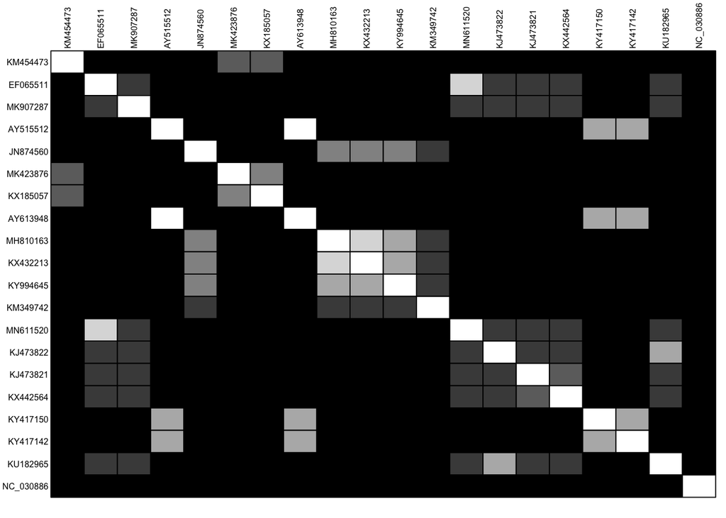

```r
BrowseSeqs(virus_seq_align, highlight=0)

writeXStringSet(virus_seq_align, file="virus_seq_align.fasta")

virus_aligned <- read.alignment("virus_seq_align.fasta", format = "fasta")

matriz_distancia <- dist.alignment(virus_aligned, matrix = "similarity")

temp <- as.data.frame(as.matrix(matriz_distancia))
table.paint(temp, cleg=0, clabel.row=.5, clabel.col=.5) + scale_color_viridis()
```